# Differential expression analysis with STAR and DEseq2

## Using DESeq2 with read counts

This R Markdown takes 3 inputs:

1. The **feature counts** merged TSV file. This can be generated from the generated from **`featureCounts`** & contains the **read counts**. For example, this can be generated by running **nf-core/rnaseq** using the **STAR** aligner.
2. The **annotation** file containing the samples and their associated metadata, like each condition
3. The **condition** of interest for example one condition we might want to analyse is simply the treatment used on the samples

```r
params$feature_counts
```

```
## [1] "merged_gene_counts.txt"
```

```r
params$annotation
```

```
## [1] "experiment.csv"
```

```r
params$condition
```

```
## [1] "treatment"
```

## Preprocessing

### 1. Loading the feature counts

We will be loading & preprocessing the feature counts file:

```r
if (params$feature_counts == "counts.RData") {
  load(params$feature_counts)
  counts <- counts$counts
} else {
  counts <- read.csv(params$feature_counts,
                           sep              = "\t",
                           header           = TRUE,
                           stringsAsFactors = FALSE,
                           check.names      = FALSE);

  # assign the rownames to the gene ID's & remove uncessary columns
  rownames(counts) <- counts[,1]
  counts <- counts[, -c(1:2)]

  # replace colnames to just the SRA id
  colnames(counts) <- sub("\\_.*", "", colnames(counts))

  # order the columns
  counts <- counts[ , order(names(counts))]
}
```

### 2. Loading the annotation

Then will have to load the information for the annotation. And make the read count matrix names match the ones in the sample table.

```r
# Load sample table with metadata
sampleTable <- read.csv(params$annotation, row.names = 1)

# Remove .bam from the filenames
colnames(counts) <- gsub("Aligned\\.out\\.bam$" , "", colnames(counts))

# Order the rows
sampleTable <- sampleTable[ order(row.names(sampleTable)), ]
```

We are going to make sure we analyse the exactly same samples we have between sample table and count data.

```r
# Match and xtract samples for the analysis and keep as a matrix
countdata <- as.matrix(counts)[, colnames(counts) %in% rownames(sampleTable)]
head(countdata)
```

```
##                 SRR7510083 SRR7510084 SRR7510085 SRR7510086 SRR7510087
## ENSG00000223972          0          0          0          0          0
## ENSG00000227232         31         42         34         50         41
## ENSG00000243485          0          0          0          0          0
## ENSG00000237613          0          0          0          0          0
## ENSG00000268020          0          0          0          0          0
## ENSG00000240361          0          0          0          0          0
##                 SRR7510088 SRR7510092 SRR7510093 SRR7510094 SRR7510095
## ENSG00000223972          0          0          0          0          0
## ENSG00000227232         58         49         47         41         42
## ENSG00000243485          0          0          0          0          0
## ENSG00000237613          0          0          0          0          0
## ENSG00000268020          0          0          0          0          0
## ENSG00000240361          0          0          0          0          0
##                 SRR7510096 SRR7510097 SRR7510101 SRR7510102 SRR7510103
## ENSG00000223972          0          1          0          0          0
## ENSG00000227232         46         32         39         43         39
## ENSG00000243485          0          0          0          0          0
## ENSG00000237613          0          0          0          0          0
## ENSG00000268020          0          0          0          0          0
## ENSG00000240361          0          0          0          0          0
##                 SRR7510104 SRR7510105 SRR7510106 SRR7510110 SRR7510111
## ENSG00000223972          0          0          0          0          0
## ENSG00000227232         38         64         45         40         74
## ENSG00000243485          0          0          0          0          0
## ENSG00000237613          0          0          0          0          0
## ENSG00000268020          0          0          0          0          0
## ENSG00000240361          0          0          0          0          0
##                 SRR7510112 SRR7510113 SRR7510114 SRR7510115 SRR7510119
## ENSG00000223972          0          0          0          0          0
## ENSG00000227232         55         73         77         67         37
## ENSG00000243485          0          0          0          0          0
## ENSG00000237613          0          0          0          0          0
## ENSG00000268020          0          0          0          0          0
## ENSG00000240361          0          0          0          0          0
##                 SRR7510120 SRR7510121 SRR7510122 SRR7510123 SRR7510124
## ENSG00000223972          0          0          0          0          0
## ENSG00000227232         40         25         46         52         45
## ENSG00000243485          0          0          0          0          0
## ENSG00000237613          0          0          0          0          0
```

[output cut: 15 more lines]

```
## ENSG00000240361          0          0          0          0          0
##                 SRR7510141 SRR7510142 SRR7510146 SRR7510147 SRR7510148
## ENSG00000223972          0          0          0          0          0
## ENSG00000227232         60         46         44         54         74
## ENSG00000243485          0          0          0          0          0
## ENSG00000237613          0          0          0          0          0
## ENSG00000268020          0          0          0          0          0
## ENSG00000240361          0          0          0          0          0
##                 SRR7510149 SRR7510150 SRR7510151
## ENSG00000223972          0          0          0
## ENSG00000227232         65         64         64
## ENSG00000243485          0          0          0
## ENSG00000237613          0          0          0
## ENSG00000268020          0          0          0
## ENSG00000240361          0          0          0
```

### 3. Setting the condition of interest

Here we select/extract the one condition we want to analyse, eg the treatment was used on each sample:

```r
condition <- unlist(sampleTable[params$condition])
condition
```

```
##   treatment1   treatment2   treatment3   treatment4   treatment5
##      vehicle      vehicle      vehicle geldanamycin geldanamycin
##   treatment6   treatment7   treatment8   treatment9  treatment10
## geldanamycin      vehicle      vehicle      vehicle geldanamycin
##  treatment11  treatment12  treatment13  treatment14  treatment15
## geldanamycin geldanamycin      vehicle      vehicle      vehicle
##  treatment16  treatment17  treatment18  treatment19  treatment20
## geldanamycin geldanamycin geldanamycin      vehicle      vehicle
##  treatment21  treatment22  treatment23  treatment24  treatment25
##      vehicle geldanamycin geldanamycin geldanamycin      vehicle
##  treatment26  treatment27  treatment28  treatment29  treatment30
##      vehicle      vehicle geldanamycin geldanamycin geldanamycin
##  treatment31  treatment32  treatment33  treatment34  treatment35
##      vehicle      vehicle      vehicle geldanamycin geldanamycin
##  treatment36  treatment37  treatment38  treatment39  treatment40
## geldanamycin      vehicle      vehicle      vehicle geldanamycin
##  treatment41  treatment42  treatment43  treatment44  treatment45
## geldanamycin geldanamycin      vehicle      vehicle      vehicle
##  treatment46  treatment47  treatment48
## geldanamycin geldanamycin geldanamycin
## Levels: geldanamycin vehicle
```

## Differential Expression Analysis

Now that we have prepared the sample and counts read data, we can start using DEseq2 as the library to perform Differential Expression analysis.

```r
suppressMessages(library(DESeq2))
```

First we create the DEseq dataset object using the read counts and the sample data.

```r
dds <- DESeqDataSetFromMatrix(countData=countdata, colData=sampleTable, design= as.formula(paste("~", params$condition)))
dds
```

```
## class: DESeqDataSet
## dim: 63677 48
## metadata(1): version
## assays(1): counts
## rownames(63677): ENSG00000223972 ENSG00000227232 ...
##   ENSG00000231514 ENSG00000235857
## rowData names(0):
## colnames(48): SRR7510083 SRR7510084 ... SRR7510150 SRR7510151
## colData names(2): treatment biological_replicate
```

Then we can run the Differential Expression pipeline with just the command:

```r
dds <- DESeq(dds)
```

```
## -- replacing outliers and refitting for 8 genes
## -- DESeq argument 'minReplicatesForReplace' = 7
## -- original counts are preserved in counts(dds)
```

### Dispersion plot

We can have a look at the dispersion of read counts across genes in all samples

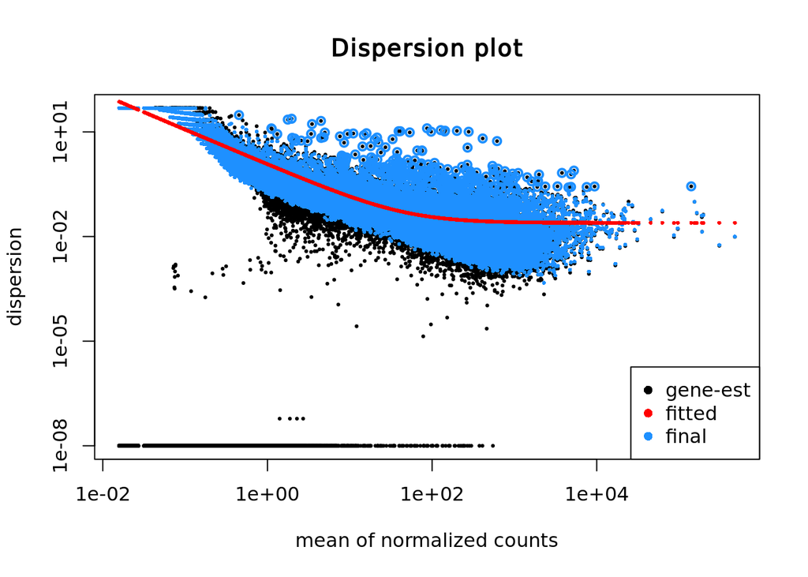

```r
plotDispEsts(dds, main="Dispersion plot")
```

### Log Transformation & Histogram

We will then apply log transformation to the read counts and will try to cluster the samples according the log transform counts

```r
# Regularized log transformation for clustering/heatmaps, etc
rld <- rlogTransformation(dds)
```

```
## rlog() may take a few minutes with 30 or more samples,
## vst() is a much faster transformation
```

```r
head(assay(rld))
```

```
##                 SRR7510083 SRR7510084 SRR7510085 SRR7510086 SRR7510087
## ENSG00000223972  -2.391182  -2.391264  -2.391236  -2.391470  -2.391558
## ENSG00000227232   5.408114   5.587919   5.451599   5.649913   5.479577
## ENSG00000243485   0.000000   0.000000   0.000000   0.000000   0.000000
## ENSG00000237613   0.000000   0.000000   0.000000   0.000000   0.000000
## ENSG00000268020   0.000000   0.000000   0.000000   0.000000   0.000000
## ENSG00000240361   0.000000   0.000000   0.000000   0.000000   0.000000
##                 SRR7510088 SRR7510092 SRR7510093 SRR7510094 SRR7510095
## ENSG00000223972  -2.391529  -2.391957  -2.392041  -2.392020  -2.391120
## ENSG00000227232   5.744326   5.478948   5.423754   5.338848   5.633152
## ENSG00000243485   0.000000   0.000000   0.000000   0.000000   0.000000
## ENSG00000237613   0.000000   0.000000   0.000000   0.000000   0.000000
## ENSG00000268020   0.000000   0.000000   0.000000   0.000000   0.000000
## ENSG00000240361   0.000000   0.000000   0.000000   0.000000   0.000000
##                 SRR7510096 SRR7510097 SRR7510101 SRR7510102 SRR7510103
## ENSG00000223972  -2.391201  -2.386637  -2.391045  -2.391133  -2.391100
## ENSG00000227232   5.674306   5.428749   5.603110   5.646033   5.586116
## ENSG00000243485   0.000000   0.000000   0.000000   0.000000   0.000000
## ENSG00000237613   0.000000   0.000000   0.000000   0.000000   0.000000
## ENSG00000268020   0.000000   0.000000   0.000000   0.000000   0.000000
## ENSG00000240361   0.000000   0.000000   0.000000   0.000000   0.000000
##                 SRR7510104 SRR7510105 SRR7510106 SRR7510110 SRR7510111
## ENSG00000223972  -2.391421  -2.391508  -2.391478  -2.391957  -2.392040
## ENSG00000227232   5.469674   5.829970   5.569814   5.341806   5.764152
## ENSG00000243485   0.000000   0.000000   0.000000   0.000000   0.000000
## ENSG00000237613   0.000000   0.000000   0.000000   0.000000   0.000000
## ENSG00000268020   0.000000   0.000000   0.000000   0.000000   0.000000
## ENSG00000240361   0.000000   0.000000   0.000000   0.000000   0.000000
##                 SRR7510112 SRR7510113 SRR7510114 SRR7510115 SRR7510119
## ENSG00000223972  -2.392008  -2.392131  -2.392229  -2.392197  -2.391099
## ENSG00000227232   5.546046   5.721543   5.730690   5.631947   5.549551
## ENSG00000243485   0.000000   0.000000   0.000000   0.000000   0.000000
## ENSG00000237613   0.000000   0.000000   0.000000   0.000000   0.000000
## ENSG00000268020   0.000000   0.000000   0.000000   0.000000   0.000000
## ENSG00000240361   0.000000   0.000000   0.000000   0.000000   0.000000
##                 SRR7510120 SRR7510121 SRR7510122 SRR7510123 SRR7510124
## ENSG00000223972  -2.391185  -2.391163   -2.39180  -2.391892  -2.391865
## ENSG00000227232   5.577688   5.284958    5.48406   5.542238   5.448405
## ENSG00000243485   0.000000   0.000000    0.00000   0.000000   0.000000
## ENSG00000237613   0.000000   0.000000    0.00000   0.000000   0.000000
```

[output cut: 15 more lines]

```
## ENSG00000240361   0.000000   0.000000   0.000000   0.000000   0.000000
##                 SRR7510141 SRR7510142 SRR7510146 SRR7510147 SRR7510148
## ENSG00000223972   -2.39196  -2.391934  -2.392085  -2.392170  -2.392147
## ENSG00000227232    5.62671   5.442212   5.365554   5.480404   5.727198
## ENSG00000243485    0.00000   0.000000   0.000000   0.000000   0.000000
## ENSG00000237613    0.00000   0.000000   0.000000   0.000000   0.000000
## ENSG00000268020    0.00000   0.000000   0.000000   0.000000   0.000000
## ENSG00000240361    0.00000   0.000000   0.000000   0.000000   0.000000
##                 SRR7510149 SRR7510150 SRR7510151
## ENSG00000223972  -2.392086  -2.392177  -2.392144
## ENSG00000227232   5.645999   5.603634   5.614586
## ENSG00000243485   0.000000   0.000000   0.000000
## ENSG00000237613   0.000000   0.000000   0.000000
## ENSG00000268020   0.000000   0.000000   0.000000
## ENSG00000240361   0.000000   0.000000   0.000000
```

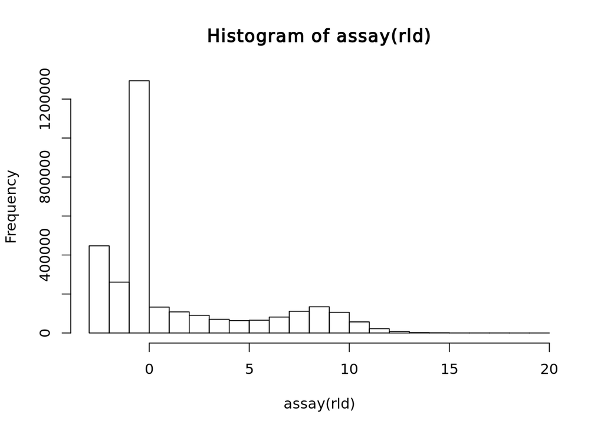

```r
hist(assay(rld))
```

### Sample Distance Matrix

```r
suppressMessages(library(RColorBrewer))
(mycols <- brewer.pal(8, "Dark2")[1:length(unique(condition))])
```

```
## [1] "#1B9E77" "#D95F02"
```

```r
sampleDists <- as.matrix(dist(t(assay(rld))))
```

By calculating distances across samples from log transformed counts we can plot the distance matrix and colour the samples according to the condition.

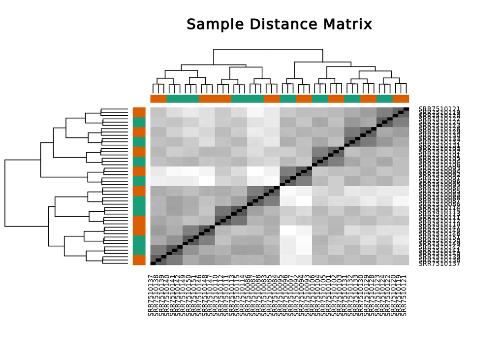

```r
suppressMessages(library(gplots))
heatmap.2(as.matrix(sampleDists), key=F, trace="none",
          col=colorpanel(100, "black", "white"),
          ColSideColors=mycols[condition], RowSideColors=mycols[condition],
          margin=c(10, 10), main="Sample Distance Matrix")
```

### PCA Biplot

```r
rld_pca <- function (rld, intgroup = "condition", ntop = 500, colors=NULL, legendpos="bottomleft", main="PCA Biplot", textcx=1, ...) {
  require(genefilter)
  require(calibrate)
  require(RColorBrewer)
  rv = rowVars(assay(rld))
  select = order(rv, decreasing = TRUE)[seq_len(min(ntop, length(rv)))]
  pca = prcomp(t(assay(rld)[select, ]))
  fac = factor(apply(as.data.frame(colData(rld)[, intgroup, drop = FALSE]), 1, paste, collapse = " : "))
  if (is.null(colors)) {
    if (nlevels(fac) >= 3) {
      colors = brewer.pal(nlevels(fac), "Paired")
    }   else {
      colors = c("black", "red")
    }
  }
  pc1var <- round(summary(pca)$importance[2,1]*100, digits=1)
  pc2var <- round(summary(pca)$importance[2,2]*100, digits=1)
  pc1lab <- paste0("PC1 (",as.character(pc1var),"%)")
  pc2lab <- paste0("PC1 (",as.character(pc2var),"%)")
  plot(PC2~PC1, data=as.data.frame(pca$x), bg=colors[fac], pch=21, xlab=pc1lab, ylab=pc2lab, main=main, ...)
  with(as.data.frame(pca$x), textxy(PC1, PC2, labs=rownames(as.data.frame(pca$x)), cex=textcx))
  legend(legendpos, legend=levels(fac), col=colors, pch=20)
}
```

```r
suppressMessages(rld_pca(rld, colors=mycols, intgroup=params$condition, xlim=c(-75, 35)))
```

[figure not shown]

### Results table of top genes by adjusted p-value

On last steps, we want to be able to filter and to extract genes based on certain thresholds. We can apply filter in order to filter for p-values and adjusted p-values on top of the results table.

```r
res <- results(dds)
table(res$padj<0.05)
```

```
##
## FALSE  TRUE
## 17444  4529
```

```r
## Order by adjusted p-value
res <- res[order(res$padj), ]

## Merge with normalized count data
resdata <- merge(as.data.frame(res), as.data.frame(counts(dds, normalized=TRUE)), by="row.names", sort=FALSE)
names(resdata)[1] <- "Gene"
head(resdata)
```

|  | Gene | baseMean | log2FoldChange | lfcSE | stat | pvalue | padj | SRR7510083 | SRR7510084 | SRR7510085 | SRR7510086 | SRR7510087 | SRR7510088 | SRR7510092 | SRR7510093 | SRR7510094 | SRR7510095 | SRR7510096 | SRR7510097 | SRR7510101 | SRR7510102 | SRR7510103 | SRR7510104 | SRR7510105 | SRR7510106 | SRR7510110 | SRR7510111 | SRR7510112 | SRR7510113 | … |
| --- | --- | --- | --- | --- | --- | --- | --- | --- | --- | --- | --- | --- | --- | --- | --- | --- | --- | --- | --- | --- | --- | --- | --- | --- | --- | --- | --- | --- | --- | --- |
| 1 | ENSG00000112972 | 742.1158 | 0.6879862 | 0.03852092 | 17.86007 | 2.413528e-71 | 5.303244e-67 | 858.7565 | 832.9670 | 863.3332 | 446.2103 | 506.9250 | 523.7477 | 955.7050 | 958.4038 | 1005.6387 | 609.7687 | 556.0016 | 581.7583 | 859.3146 | 861.1349 | 917.5915 | 604.5362 | 606.8308 | 578.9836 | 880.5154 | 919.2444 | 870.2888 | 510.4897 | … |
| 2 | ENSG00000138801 | 1811.7145 | 0.3014070 | 0.01794460 | 16.79653 | 2.587619e-63 | 2.842888e-59 | 2014.2182 | 1933.5073 | 1942.2053 | 1608.4820 | 1727.2242 | 1645.7685 | 1770.8400 | 1906.8930 | 1831.1630 | 1598.7838 | 1590.2842 | 1661.9940 | 2005.4942 | 2085.6960 | 2048.9542 | 1619.3321 | 1616.8228 | 1582.4139 | 2108.2643 | 2077.3932 | 2041.5735 | 1656.9082 | … |
| 3 | ENSG00000114796 | 1971.6338 | -0.4376615 | 0.02764019 | -15.83425 | 1.806088e-56 | 1.322839e-52 | 1765.7578 | 1855.5620 | 1745.5114 | 2115.2494 | 2159.5412 | 2190.2176 | 1659.4125 | 1682.1639 | 1725.2624 | 2476.2558 | 2232.3764 | 2397.0372 | 1618.7386 | 1517.7657 | 1478.8974 | 2110.9926 | 2047.1400 | 2076.7198 | 1888.7785 | 1942.6478 | 1888.9795 | 2294.4248 | … |
| 4 | ENSG00000099194 | 873.1951 | 1.7661115 | 0.11220162 | 15.74052 | 7.979014e-56 | 4.383072e-52 | 1454.5791 | 1541.4543 | 1512.3054 | 325.0961 | 364.8633 | 343.6447 | 1209.4168 | 1170.7398 | 1194.0917 | 323.4749 | 334.7967 | 345.1927 | 1365.1704 | 1363.7717 | 1381.3877 | 423.2839 | 444.9396 | 474.1949 | 1145.4417 | 1107.7226 | 1120.9790 | 233.4121 | … |
| 5 | ENSG00000198839 | 307.6317 | -0.5152102 | 0.03413599 | -15.09287 | 1.804070e-51 | 7.928167e-48 | 268.9645 | 274.5534 | 289.7408 | 393.0900 | 380.1937 | 357.1007 | 229.7121 | 228.0340 | 229.3123 | 316.0387 | 349.1451 | 362.0902 | 283.0231 | 253.7823 | 275.0274 | 352.7365 | 350.9383 | 364.1140 | 227.2021 | 265.3574 | 228.0526 | 362.8208 | … |
| 6 | ENSG00000152409 | 798.5602 | -0.3217805 | 0.02148562 | -14.97655 | 1.045024e-50 | 3.827051e-47 | 720.0529 | 718.9576 | 666.6393 | 776.6184 | 864.6341 | 840.4805 | 686.5648 | 751.8512 | 705.4480 | 883.6689 | 915.9081 | 887.1210 | 703.0755 | 649.2391 | 712.5710 | 900.8349 | 873.1679 | 866.8876 | 704.7553 | 703.4865 | 751.2320 | 882.0436 | … |

```r
## Write results
write.csv(resdata, file="diffexpr-results.csv")
```

### Histogram of p-value

There are also several plots available for quality control on top of the results we got that we can explore, like the histogram of significance levels.

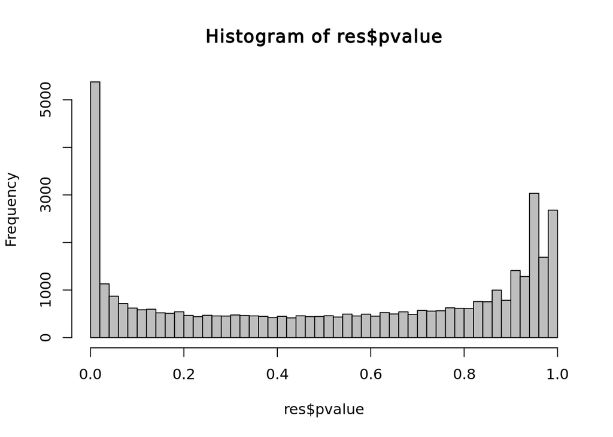

```r
hist(res$pvalue, breaks=50, col="grey")
```

### MA Plot

```r
maplot <- function (res, thresh=0.05, labelsig=TRUE, textcx=1, ...) {
  with(res, plot(baseMean, log2FoldChange, pch=20, cex=.5, log="x", ...))
  with(subset(res, padj<thresh), points(baseMean, log2FoldChange, col="red", pch=20, cex=1.5))
  if (labelsig) {
    require(calibrate)
    with(subset(res, padj<thresh), textxy(baseMean, log2FoldChange, labs=Gene, cex=textcx, col=2))
  }
}
```

Also the MA plot, where we can see how the log fold changes compare against the mean averages across genes

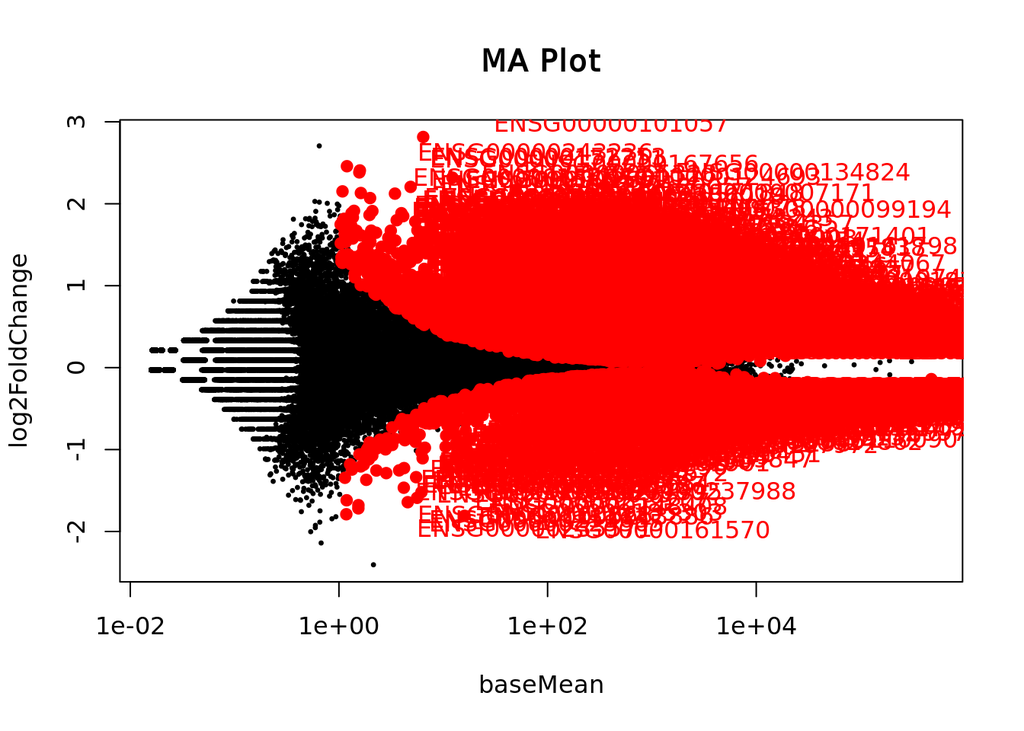

```r
maplot(resdata, main="MA Plot")
```

### Volcano plot

The last plot we show is the volcano plot, where we can visualize what’s the relationship between log fold changes and significance levels in our test.

```r
volcanoplot <- function (res, lfcthresh=2, sigthresh=0.05, main="Volcano Plot", legendpos="bottomright", labelsig=TRUE, textcx=1, ...) {
  with(res, plot(log2FoldChange, -log10(pvalue), pch=20, main=main, ...))
  with(subset(res, padj<sigthresh ), points(log2FoldChange, -log10(pvalue), pch=20, col="red", ...))
  with(subset(res, abs(log2FoldChange)>lfcthresh), points(log2FoldChange, -log10(pvalue), pch=20, col="orange", ...))
  with(subset(res, padj<sigthresh & abs(log2FoldChange)>lfcthresh), points(log2FoldChange, -log10(pvalue), pch=20, col="green", ...))
  if (labelsig) {
    require(calibrate)
    with(subset(res, padj<sigthresh & abs(log2FoldChange)>lfcthresh), textxy(log2FoldChange, -log10(pvalue), labs=Gene, cex=textcx, ...))
  }
  legend(legendpos, xjust=1, yjust=1, legend=c(paste("FDR<",sigthresh,sep=""), paste("|LogFC|>",lfcthresh,sep=""), "both"), pch=20, col=c("red","orange","green"))
}
```

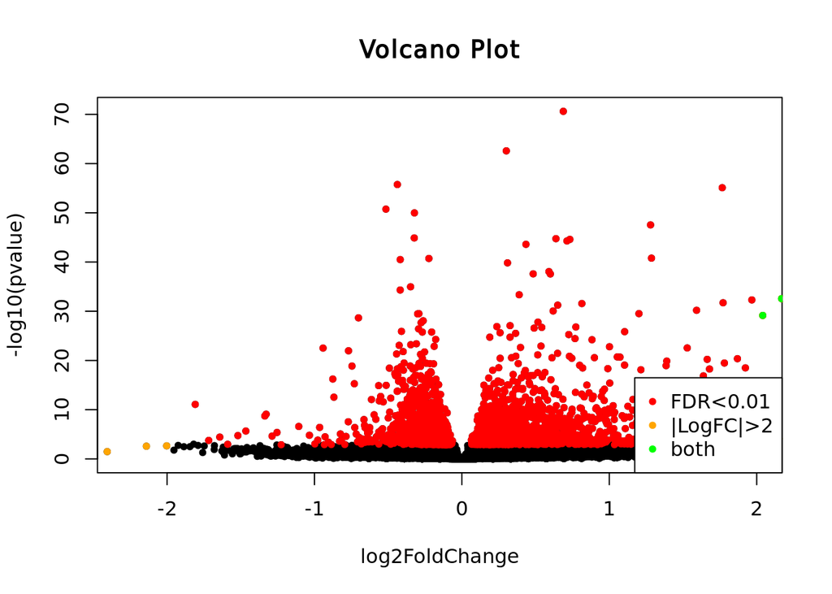

```r
volcanoplot(resdata, lfcthresh=2, sigthresh=0.01, textcx=.8, xlim=c(-2.3, 2))
```